## Lecture 7 : Market Efficiency and the Behavioral Critique

# Refresher

- Recall our last lectures suggested a number of failures of the CAPM (small cap, value, momentum)
- One response has been the advent of factor models
- Characteristics of stocks which generate alpha can be better represented as factor exposures
  - i.e. small stocks returns driven by factor sensitivity and the SMB risk premium

# Anomalies: risks or opportunities?

- Note the theme:
  - Shares are generally correctly priced
  - Risk-premia paid on assets represent exposure to risk facors
  - Otherwise, “arbitrageurs” will quickly drive prices to equilibrium
- *No free lunch* $\longrightarrow$ high-returns = high risk

# Market Efficiency

- These ideas are closely associated with the efficient market hypothesis (EMH)
  - Specifically, EMH posits that prices reflect all available information
- The EMH comes in three flavors:
  1. Weak form: all available information is limited to historical prices
  2. Semi-strong form: all available data refers to all publicly available data
  3. Strong form: all available information includes insider information

# Examples (weak form)

- Weak form: all available information is limited to historical prices
- Empirical evidence shows that using historical data, we can predict:
  1. Short-run reversals
  2. medium momentum
  3. long-term reversals
- More recently evidence on return seasonals (Heston Sadka 2008)
- In the longer run, there is definitely return predictability…but that doesn’t necessarily imply markets are inefficient

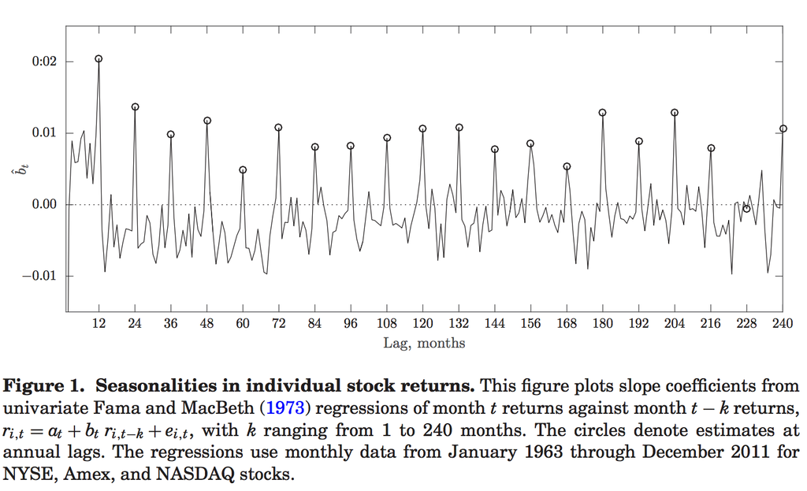

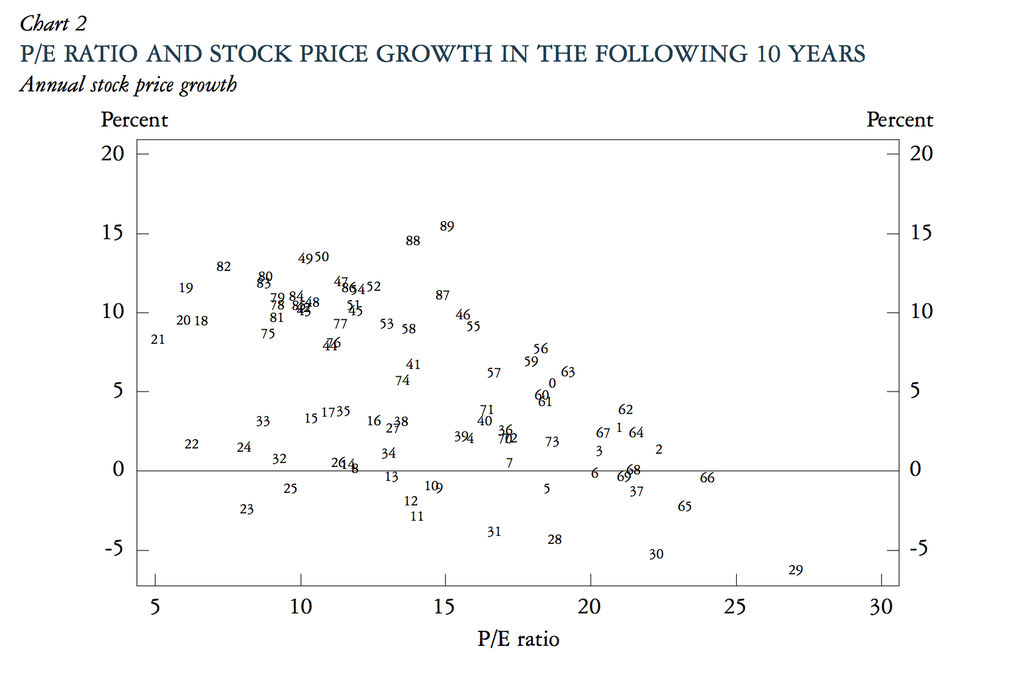

# Examples (semi-strong)

- Da, Engelberg, and Gao (2010 and 2011) showed that it took time for markets to recognize value in new public information produced by Google trends
- Google search volume based on products predicted earnings better than both analyst forecasts and earnings announcement returns
- Search volume also proxied for retail investor interest:
  - An increase predicts higher stock prices in the next 2 weeks and an eventual price reversal within the year.
  - It also contributes to the large first-day return and long-run underperformance of IPO stocks.

# Examples (strong)

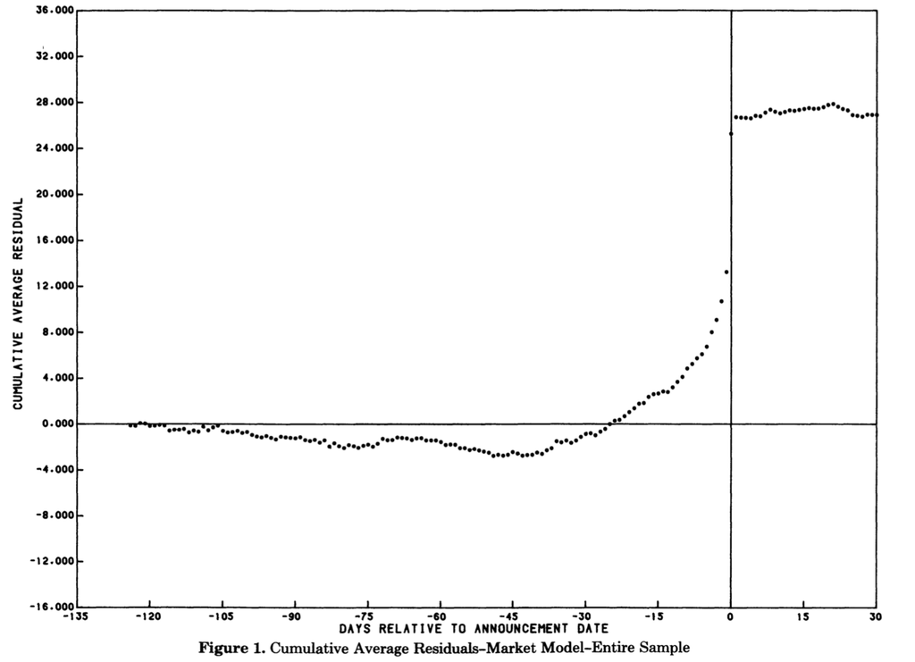

# The Behavioral Critique

- In contrast to the EMH, behavioral view suggests prices may be wrong
- Two departures from the EMH:
  1. Irrational investors
  2. Limits to arbitrage
- This leads to investors who make systematic errors in pricing securities, and ensures that attempts to exploit/correct mispricings are risky or costly

# The Behavioral Critique

- Let’s begin with “investor irrationality”
- Some key ideas about how investors may behave irrationally
  - Overconfidence
  - Representativeness
  - Inattention

# Overconfidence

- Two types:
  1. Overprecision
     - People are too confident in the accuracy of their beliefs
     - 90% confidence intervals contain correct answers less than 50% of the time
  2. Overplacement
     - Overly rosy views of their abilities
     - In surveys, 90% believe themselves to be above the median on various dimensions

# Overconfidence: Applications

- View in finance research: excessive trading by individual (retail) investors
- Barber and Odean (2002) show male traders trade more and do worse
  - Psychological studies suggest men more prone to overconfidence
- Grinblatt and Keloharju (2009) combine trading data with psychological tests of overconfidence
  - Overconfidence linked to intensity of trading activity

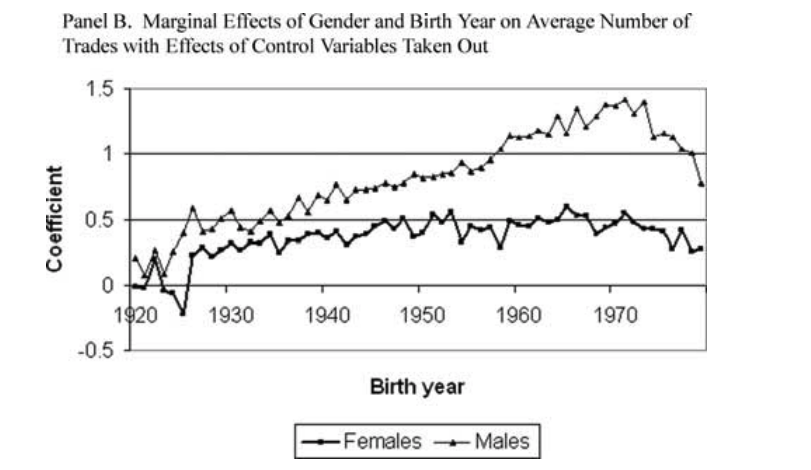

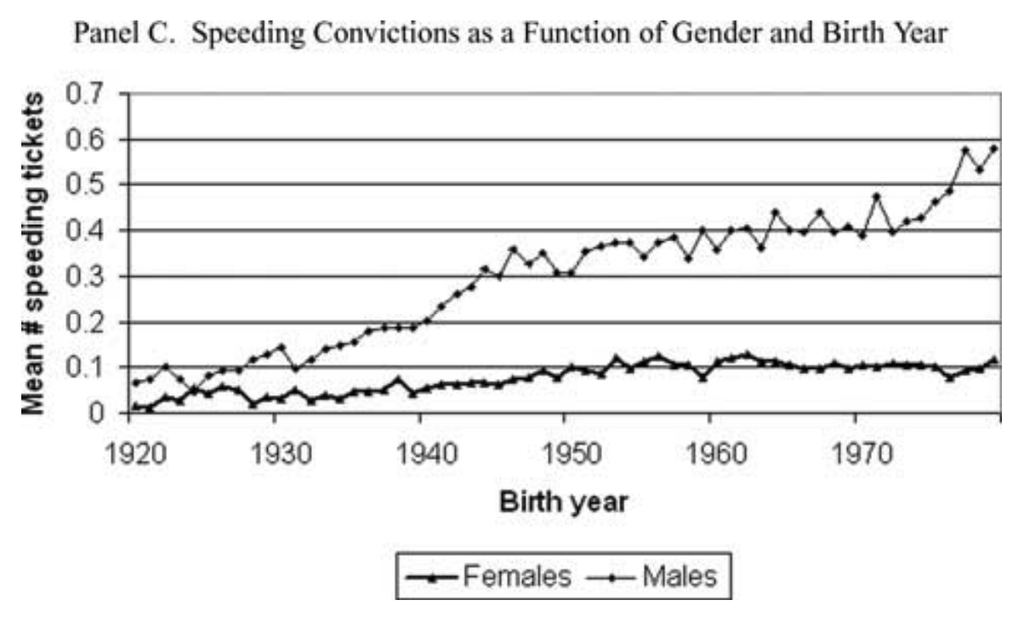

# Representativeness

- People extrapolate past trends too far into the future
- Just because a firm has seen high growth for past five years does not necessarily mean it will continue
- In revising their beliefs, individuals tend to overweight recent information and underweight prior (or base rate) data.
  - “The predicted value is selected so that the standing of the case in the distribution of outcomes matches its standing in the distribution of impressions” (Kahnemann and Tversky)

# Representativeness: Applications

- Representativeness predicts long‐run mean reversion in stock returns (De Bondt and Thaler (1985)):
- Exercise:
  1. Take a three year period and rank stocks on their performance over that period
  2. Form a “losers” (“winners”) portfolio of the 30 worst-performing (best-performing) stocks, and hold for three years
  3. Repeat process three years later
- Result: past winners do poorly, past losers rebound
  - Note: observe short term momentum, but long‐run reversals

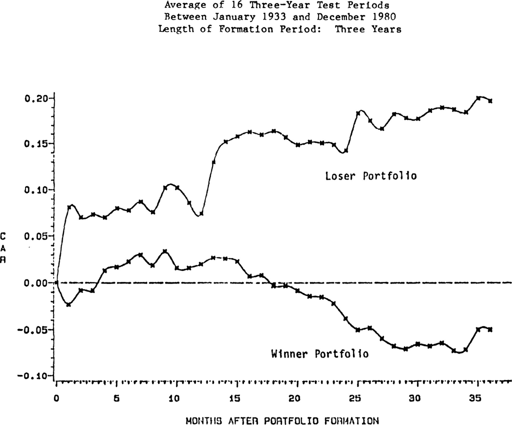

# Other examples of over‐extrapolation

- Value premium may reflect over‐extrapolation about future growth rates
- Low book‐to‐market firms priced based on expectations that recent growth will continue
- Growth stocks tend to disappoint in earnings announcements
- Earnings disappointments more severe for growth stocks

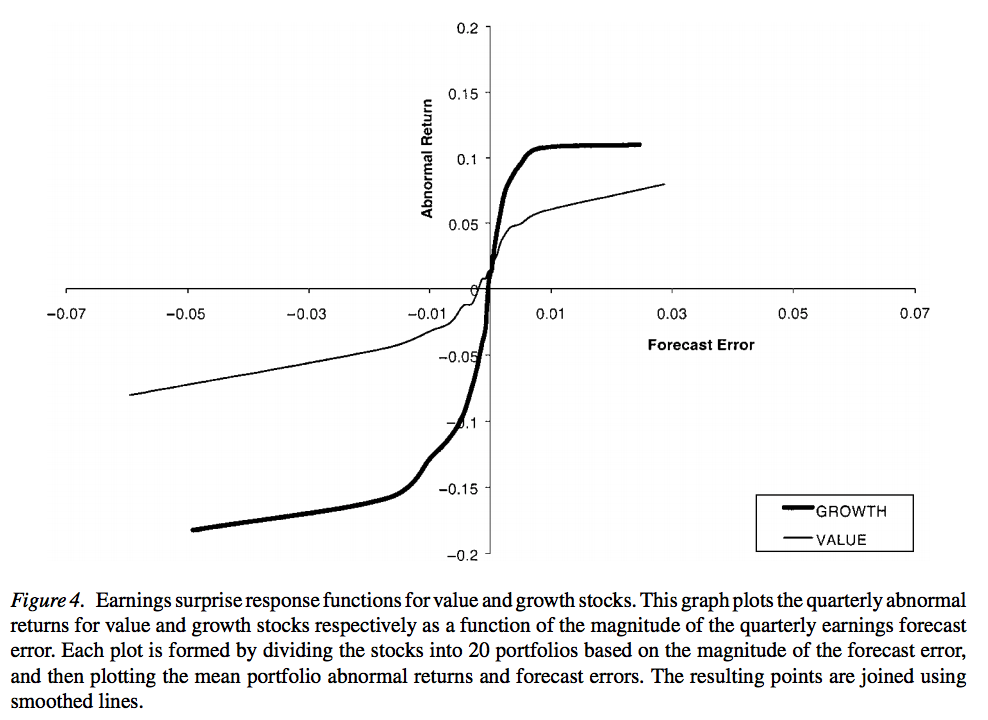

# Inattention

- People have limited capacity for gathering and processing information
  - Application: Post‐earnings announcement drift
  - After earnings surprises, returns drift for as long as 60 days
    - Larger for Friday announcements
    - Larger for firms announcing at same time as other firms
- See also Niessner (2014), Cohen Frazzini (2008)

# Niessner (2014)

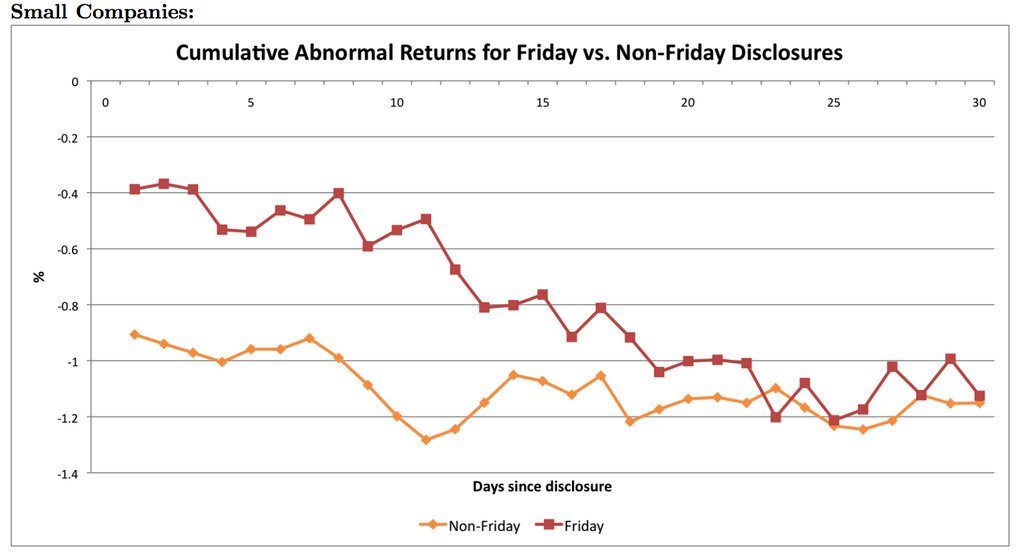

# Cohen Frazzini (2008)

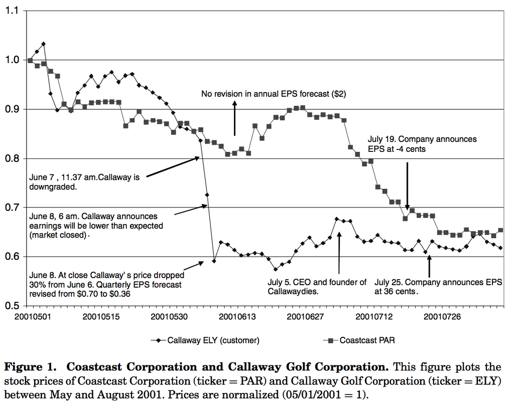

# Question: Why don’t “arbitrageurs” exploit mispricing?

- The second piece of the behavioral framework
  - “limits to arbitrage”
  - Recall our willingness to take active positions is driven by not just opportunity, but by the idiosyncratic risk associated with the reward
  - E.g. Treynor-black:
    $$w_{i}^{0} = \frac{\alpha_{i} / \sigma_{i}^{2}(\epsilon)}{\sum_{j}\alpha_{j} / \sigma_{j}^{2}(\epsilon)}$$

# Why don’t “arbitrageurs” exploit mispricing?

- Royal Dutch and Shell Transport merge interests, but continue to trade separately in the Netherlands and the UK

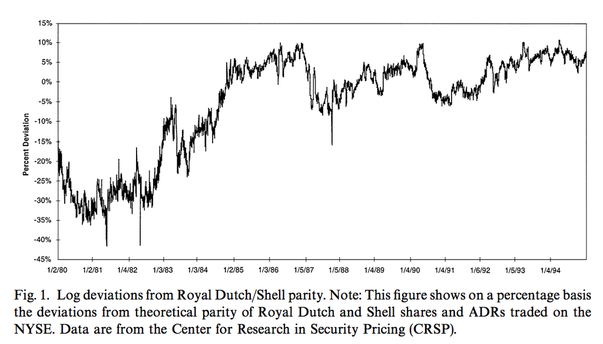

- Note: a long‐short position is risky (why?)
  - Behavioral biases generating mispricing may get worse, not better

# Behavioral Finance and the EMH

- Anomalies reflect a failure in the efficient markets / rational investor model
- Behavioral finance may provides answers, based on known biases from cognitive psychology